# FuboTV (FUBO)

- The only streaming service to offer select live sporting events in crisp 4K HDR resolution
- Average revenue per user (ARPU) for the platform has gone from $37.93/month in 2018 to $53.73 last year to $67.70 in its latest quarter
- Average cost per user $40.59 to $56.78 in that time
- Started in 2015, $7 a month, with a couple of soccer-centric channels
- relaunching in 2017 as a $35-a-month service offering a broad range of live television channels
- Covid decrease: 316,000 paid subscribers to just 286,126 through the first six months of 2020. Q3 2020 back to 455,000 paid subscribers. At its peak in 2011, ESPN had more than 100 million subscribers
- Ad revenue is a smaller part of the business, but it’s growing even faster (up 153% to $7.5 million)

## News and Resources

- [Forbes Article](https://www.forbes.com/sites/bethkindig/2021/12/31/fubotv-solid-positioning-for-sports-betting/?sh=4a74fe429cb5)
- [Fool Article](https://www.fool.com/premium/rule-breakers/coverage/1069/coverage/updates/2020/12/17/buy-fubotv/)
- [Q320 Report](https://www.businesswire.com/news/home/20201110005911/en/fuboTV-Announces-Q3-2020-Results)
- [Jul 2020 Interview with CEO](https://youtu.be/IJnBoa3osKc)
- Dec 15: Live TV Streaming Platform Comes Pre-Installed in all Hisense Smart TVs [Article](https://www.businesswire.com/news/home/20201215005147/en/fuboTV-Now-Available-in-Market-on-VIDAA-Smart-OS)

## Stats

As of 2021-01-03

- Market cap 1.89B
- Revenue: Q320: 61,202 Q220:44,172 Q120:7,295

## Price

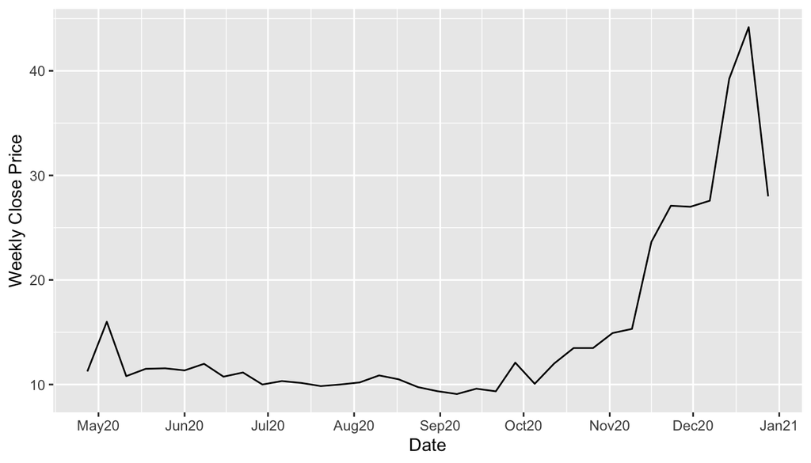

## Misc

[figure not shown]

[figure not shown]

[Source](https://twitter.com/HedgeyeComm/status/1345079085215723520?s=20)

[figure not shown]

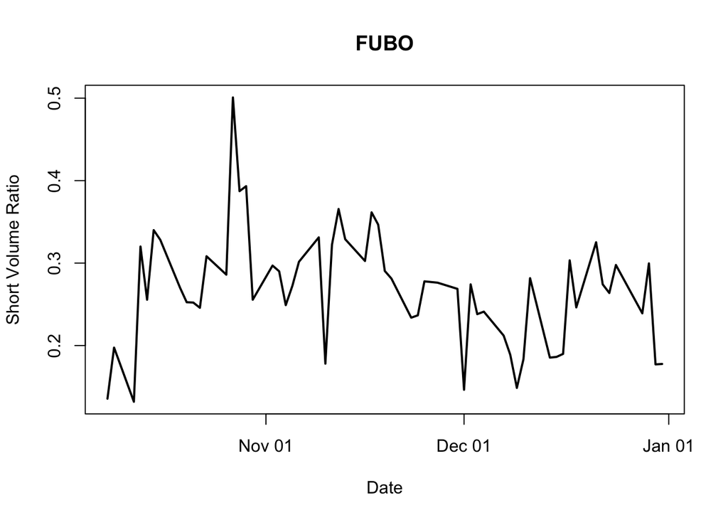

```r
plot(sv$Date,sv$ShortVolume/sv$volume,type='l', ylab="Short Volume Ratio", xlab="Date",main="FUBO", lwd = 2)
```